# Traffic_Sign_Classifier

#### Host environment

- Ubuntu 16.04
- Anaconda 4.4.10
- Python 3.6.4
- TensorFlow 1.7.0 (GPU support)
- GPU : NVIDIA GeForce GTX 1070

### Step 0. Preamble all Utility Functions will be defined here

```python
import os
import math
import pickle
import csv
from PIL import Image
# TODO: Fill this in based on where you saved the training and testing data

import matplotlib.pyplot as plt
import cv2
import numpy as np
import random
%matplotlib inline

from sklearn.utils import shuffle

""""
Image Utility functions
"""
def word_wrap(line, wrap=5):
    if len(line.split(' ')) >= wrap:
        line = line.split(' ')
        line.insert(wrap, "\n")
        return' '.join(line)
    else:
        return line

def image_show(images,
               image_titles=[],
               image_name='',
               cmap=None,
               save=False,
               horizontal=False,
               cols=4,
               ):

    """
    Shows the image takes in image data set, image_name, cmap, save or not, no of cols and image titles
    """
    SAVE_DIR = "images_output/"
    directory = ''
    cols = cols
    rows = int(math.ceil(len(images) / cols))
    plt.figure (figsize=(8,12))
    image_titles = list(map(word_wrap, image_titles))

    #iterate over the image
    for i, image in enumerate(images):
        plt.subplot(rows, cols, i+1)
        #use gray scale for only 1 channel
        if len(image.shape) == 3 and image.shape[2] == 1:
            cmap = 'gray'
            image = image.squeeze()
        if len(image.shape) == 2:
            cmap = 'gray'

        plt.imshow(image, cmap=cmap)
        if len(image_titles) == len(images):
            plt.title(image_titles[i])

        plt.xticks([])
        plt.yticks([])
        plt.tight_layout(pad=0, h_pad=0, w_pad=0)

    #If saving is passed.
    if save:
        if os.path.isdir(SAVE_DIR):
            directory = SAVE_DIR
        image_name = str(datetime.datetime.now()).split('.')[0].replace(' ', '').replace(
            ':', '').replace('-', '') if image_name == '' else image_name
        plt.savefig(directory + image_name + '.png', bbox_inches='tight')
        # plt.tight_layout()
    plt.show()


def show_img_4(images, image_titles=[]):
    plt.figure(figsize=(6, 2))
    for i in range(0,4):
        plt.subplot(1, 3, i+1)
        plt.imshow(images[i])
        plt.title(image_titles[i])
    plt.show()


def random_images_frm_dataset(dataset, dataset_y, ylabel="", cmap=None):

    plt.figure(figsize=(15, 16))
    for i in range(6):
        plt.subplot(1, 6, i+1)
        index = random.randint(0, len(dataset))
        cmap = 'gray' if len(dataset[index].shape) == 2 else cmap
        plt.imshow(dataset[index], cmap = cmap)
        plt.xlabel(signs[dataset_y[index]])
        plt.ylabel(ylabel)
        plt.xticks([])
        plt.yticks([])
    plt.tight_layout(pad=0, h_pad=0, w_pad=0)
    plt.show()
```

## Step 1. Load data

We already have three .p files of 32x32 resized images, which can be downloaded from here : [dataset download here](https://s3-us-west-1.amazonaws.com/udacity-selfdrivingcar/traffic-signs-data.zip)

- train.p: The training set.
- test.p: The testing set.
- valid.p: The validation set.
- signnames.csv: mapping of labels to training set.

We will use Python pickle to load the data.

```python
# Loading the data
training_file = "./train.p"
validation_file="./valid.p"
testing_file = "./test.p"
signname_file = "./signnames.csv"

#Load the training file, validation file and testing file.
#Using Pickle more documentationa about this class is here : https://docs.python.org/3.1/library/pickle.html
try:
    with open(training_file, mode='rb') as f:
        train = pickle.load(f)
    with open(validation_file, mode='rb') as f:
        valid = pickle.load(f)
    with open(testing_file, mode='rb') as f:
        test = pickle.load(f)

except pickle.UnpicklingError:
    raise

except (AttributeError,  EOFError, ImportError, IndexError) as e:
    # secondary errors
    print(traceback.format_exc(e))
    raise

except Exception as e:
    # everything else, possibly fatal
    raise

# Load the signale name file as well
try:
    with open(signname_file) as f:
        f.readline()
        signnames = [row[1] for row in csv.reader(f)]  #start from row[1] to skip headers

except IOError:
    print("could not read file", f)
    raise
except: #handle other exceptions such as attribute errors
   print("Unexpected error:", sys.exc_info()[0])
```

## Step 2: Dataset Summary & Exploration

The pickled data is a dictionary with 4 key/value pairs:

- `'features'` is a 4D array containing raw pixel data of the traffic sign images, (num examples, width, height, channels).
- `'labels'` is a 1D array containing the label/class id of the traffic sign. The file `signnames.csv` contains id -> name mappings for each id.
- `'sizes'` is a list containing tuples, (width, height) representing the original width and height the image.
- `'coords'` is a list containing tuples, (x1, y1, x2, y2) representing coordinates of a bounding box around the sign in the image. **THESE COORDINATES ASSUME THE ORIGINAL IMAGE. THE PICKLED DATA CONTAINS RESIZED VERSIONS (32 by 32) OF THESE IMAGES**

Complete the basic data summary below. Use python, numpy and/or pandas methods to calculate the data summary rather than hard coding the results. For example, the [pandas shape method](http://pandas.pydata.org/pandas-docs/stable/generated/pandas.DataFrame.shape.html) might be useful for calculating some of the summary results.

### Provide a Basic Summary of the Data Set Using Python, Numpy and/or Pandas

```python
X_train, y_train = train['features'], train['labels']
X_valid, y_valid = valid['features'], valid['labels']
X_test, y_test = test['features'], test['labels']


#Lets see what kind of data is loaded and visualize our data
print(" Number of training examples =", X_train.shape[0])
print(" Number of validation examples =", len(X_valid))
print(" Nuber of testing examples = ", len(X_test))

#print image width and height
examples, height, width, channels = X_train.shape[0], X_train.shape[1], X_train.shape[2], X_train.shape[3]
print(" No of Examples=",examples, "height x width=", height,"X", width, "channels=", channels)

#Number of classes
n_classes = len(signnames)
print(" Number of classes from =", n_classes)
```

```
 Number of training examples = 34799
 Number of validation examples = 4410
 Nuber of testing examples =  12630
 No of Examples= 34799 height x width= 32 X 32 channels= 3
 Number of classes from = 43
```

```python
### Replace each question mark with the appropriate value.

# TODO: Number of training examples
n_train = len(y_train)

# TODO: Number of testing examples.
n_test = len(y_test)

# TODO: What's the shape of an traffic sign image?
image_shape = image_shape = X_train.shape

# TODO: How many unique classes/labels there are in the dataset.
n_classes = len(np.unique(y_train))

img_size=X_train.shape[1] #Size of input images

print("Number of training examples =", n_train)
print("Number of testing examples =", n_test)
print("Image data shape =", image_shape)
print("Number of classes =", n_classes)
```

```
Number of training examples = 34799
Number of testing examples = 12630
Image data shape = (34799, 32, 32, 3)
Number of classes = 43
```

## Step 2: Design and Test a Model Architecture

Design and implement a deep learning model that learns to recognize traffic signs. Train and test your model on the [German Traffic Sign Dataset](http://benchmark.ini.rub.de/?section=gtsrb&subsection=dataset).

The LeNet-5 implementation shown in the classroom at the end of the CNN lesson is a solid starting point. You'll have to change the number of classes and possibly the preprocessing, but aside from that it's plug and play!

With the LeNet-5 solution from the lecture, you should expect a validation set accuracy of about 0.89. To meet specifications, the validation set accuracy will need to be at least 0.93. It is possible to get an even higher accuracy, but 0.93 is the minimum for a successful project submission.

There are various aspects to consider when thinking about this problem:

- Neural network architecture (is the network over or underfitting?)
- Play around preprocessing techniques (normalization, rgb to grayscale, etc)
- Number of examples per label (some have more than others).
- Generate fake data.

Here is an example of a [published baseline model on this problem](http://yann.lecun.com/exdb/publis/pdf/sermanet-ijcnn-11.pdf). It's not required to be familiar with the approach used in the paper but, it's good practice to try to read papers like these.

```python
signs = []
with open('signnames.csv', 'r') as csvfile:
    signnames = csv.reader(csvfile, delimiter=',')
    next(signnames,None)
    for row in signnames:
        signs.append(row[1])
    csvfile.close()
```

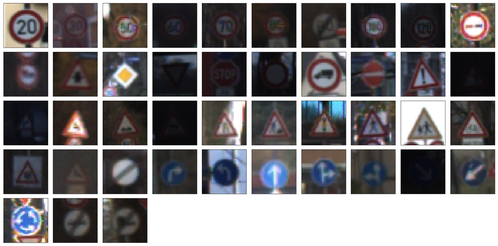

```python
#Visualizing the data
plt.figure(figsize=(28, 14))
plt.subplots_adjust(hspace = .1, wspace= .1)
for i in range(0, n_classes):
        index = np.where(y_train==i)[0][0]
        image = X_train[index]
        plt.subplot(5, 10, i + 1), plt.imshow(image)
        plt.xticks([]),plt.yticks([])
plt.savefig('./trafficsigns_input.jpg')
```

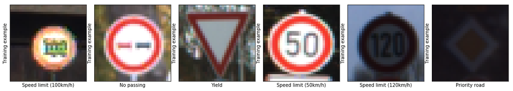

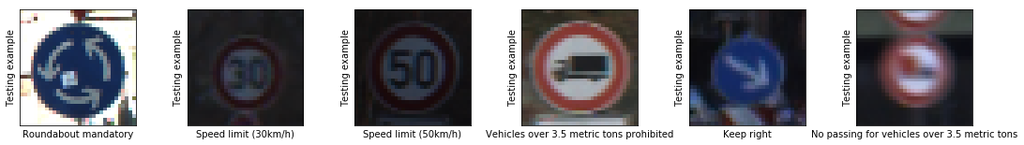

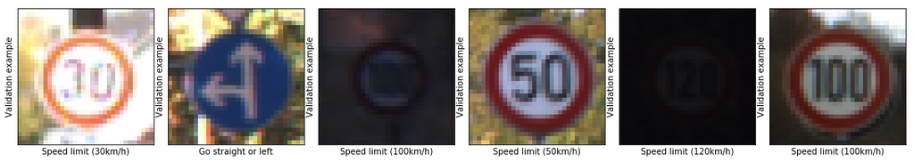

```python
# Plotting sample examples
random_images_frm_dataset(X_train, y_train, "Training example")
random_images_frm_dataset(X_test, y_test, "Testing example")
random_images_frm_dataset(X_valid, y_valid, "Validation example")
```

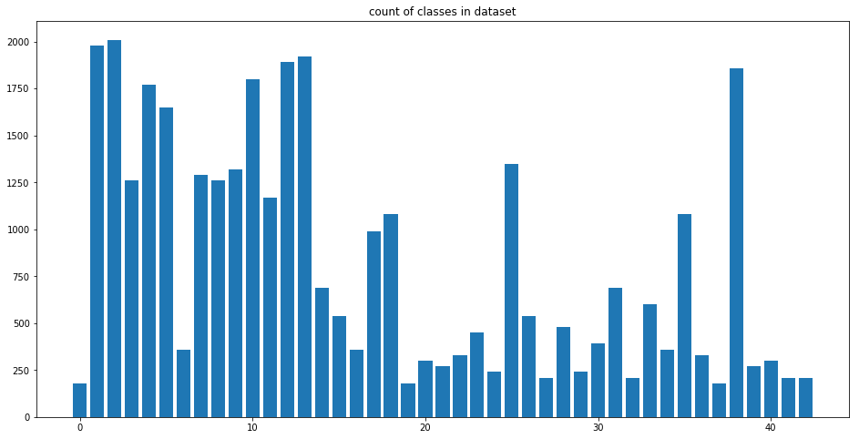

```python
def get_Histogram(x):
    return np.histogram(x, bins=np.arange(0,n_classes+1))

fig = plt.figure(figsize=(16, 8))
plt.bar(left=np.arange(0,n_classes), height=get_Histogram(y_train)[0], width=0.8, align='center')
plt.title('count of classes in dataset')
plt.show()
```

### Step 3. Pre-Process the Data Set

In this section we can do many things such as normalizing the input so that the data has mean zero and equal variance. For image data we can normalize easily using (pixel - 128)/128.

There are other processing steps which can be optional. As we progress following are the options that we can explore.

1. Grayscaling
2. Data Normalization or Standardization
3. Exploring various contract and brightness aspects
4. Image enhancements, applying various filters
5. Shuffling our dataset
6. Data Augmentation
7. CLAHE Contrast Limited Adaptive Histogram Equalization [link here](https://docs.opencv.org/3.1.0/d5/daf/tutorial_py_histogram_equalization.html)
8. Applying perception algorithms to normalize the image data

As mentioned in the FAQ video other pre-processing steps are optional. We can try different steps to see if it improves performance.

### Include an exploratory visualization of the dataset

Visualize the German Traffic Signs Dataset using the pickled file(s). This is open ended, suggestions include: plotting traffic sign images, plotting the count of each sign, etc.

The [Matplotlib](http://matplotlib.org/) [examples](http://matplotlib.org/examples/index.html) and [gallery](http://matplotlib.org/gallery.html) pages are a great resource for doing visualizations in Python.

**NOTE:** It's recommended you start with something simple first. If you wish to do more, come back to it after you've completed the rest of the sections. It can be interesting to look at the distribution of classes in the training, validation and test set. Is the distribution the same? Are there more examples of some classes than others?

[figure not shown]

```python
img_size=X_train.shape[1]

def normalize(img):
    image=img.copy()
    return (image - np.mean(image)) / np.std(image)


def normalize_new(img):
    return img.astype(np.float32) / 128. - 1.

def normalize_data(data):
    return data / 255 * 0.8 + 0.1


def convert_to_gray(img, expand=False):
    image = cv2.cvtColor(img, cv2.COLOR_RGB2GRAY)
    return np.expand_dims(image, axis=-1)


def image_histo_equalize(img):
    #Histogram Equalization
    img_new=img.copy()
    img_new[:, :, 0] = cv2.equalizeHist(img[:, :, 0])
    img_new[:, :, 1] = cv2.equalizeHist(img[:, :, 1])
    img_new[:, :, 2] = cv2.equalizeHist(img[:, :, 2])
    return img_new

def CLAHE_histogram_RGB_image(img):
    lab = cv2.cvtColor(img, cv2.COLOR_BGR2LAB)
    lab_planes = cv2.split(lab)
    clahe = cv2.createCLAHE(clipLimit=2.0,tileGridSize=(3,3))
    lab_planes[0] = clahe.apply(lab_planes[0])
    lab = cv2.merge(lab_planes)
    img = cv2.cvtColor(lab, cv2.COLOR_LAB2BGR)
    return img

def CLAHE_histogram_equalization(img):
    img = convert_to_gray(img)
    clahe = cv2.createCLAHE(clipLimit=2.0, tileGridSize=(3, 3))
    image = clahe.apply(img)
    return np.expand_dims(image, axis=-1)

def image_scale(img):
    img_new=img.copy()
    sc_y=0.4*np.random.rand()+1.0
    img_new=cv2.resize(img, None, fx=1, fy=sc_y, interpolation = cv2.INTER_CUBIC)
    c_x,c_y, sh = int(img_new.shape[0]/2), int(img_new.shape[1]/2), int(img_size/2)
    return img_new

def image_crop(img, mar=0):
    c_x,c_y, sh = int(img.shape[0]/2), int(img.shape[1]/2), int(img_size/2-mar)
    return img[(c_x-sh):(c_x+sh),(c_y-sh):(c_y+sh)]

def image_rotate(img):
    c_x,c_y = int(img.shape[0]/2), int(img.shape[1]/2)
    ang = 30.0*np.random.rand()-15
    Mat = cv2.getRotationMatrix2D((c_x, c_y), ang, 1.0)
    return cv2.warpAffine(img, Mat, img.shape[:2])

def image_sharpen(img):
    gb = cv2.GaussianBlur(img, (5,5), 20.0)
    return cv2.addWeighted(img, 2, gb, -1, 0)

def lin_img(img,s=1.0,m=0.0):
    img2=cv2.multiply(img, np.array([s]))
    return cv2.add(img2, np.array([m]))

def contr_img(img, s=1.0):
    m=127.0*(1.0-s)
    return lin_img(img, s, m)

def transform_img(img):
    img_new=image_sharpen(img)
    img_new=image_crop(img_new,3)
    img_new=contr_img(img_new, 1.5)
    return  CLAHE_histogram_RGB_image(img_new)

def augment_img(img):
    img=contr_img(img, 1.8*np.random.rand()+0.2)
    img=image_rotate(img)
    img=image_scale(img)
    return transform_img(img)



x_selected = X_train[y_train == 1]
image=x_selected[10, :, :, :]
imp=contr_img(image, 2.5)


images = [image, transform_img(image), augment_img(image), normalize_data(image)]
image_titles = ["normal image", "Transform image", "Augument Image", "Transform + Normalize"]

#show_img_4(images, image_titles)
image_show(images,image_titles)
```

### Pre-process the Data Set (normalization, grayscale, etc.)

Minimally, the image data should be normalized so that the data has mean zero and equal variance. For image data, `(pixel - 128)/ 128` is a quick way to approximately normalize the data and can be used in this project.

Other pre-processing steps are optional. You can try different techniques to see if it improves performance.

Use the code cell (or multiple code cells, if necessary) to implement the first step of your project.

```python
### Preprocess the data here.
### Feel free to use as many code cells as needed.

def preprocess(data):
    processed_images = []
    for image in data:
        image = transform_img(image)
        image = normalize_data(image)
        processed_images.append(image)

    return np.array(processed_images)

process_img_pickle_file = './processed_img_file'

def save_processed(X_train, y_train, X_valid, y_valid, X_test, y_test, signnames):
    pickle_file = process_img_pickle_file
    if not os.path.isfile(pickle_file):
        print('Saving data to pickle file...')
        try:
            with open(pickle_file, 'wb') as pfile:
                pickle.dump(
                {
                    'train_features': X_train,
                    'train_labels': y_train,
                    'valid_features': X_valid,
                    'valid_labels': y_valid,
                    'test_features': X_test,
                    'test_labels': y_test,
                    'signnames': signnames,
                },
                pfile, protocol=2)
        except Exception as e:
            print('Unable to save data to', pickle_file, ':', e)
            raise

    print('Data cached in pickle file.')

def load_processed():
    with open(process_img_pickle_file, 'rb') as f:
        pickle_data = pickle.load(f)
        X_train = pickle_data['train_features']
        y_train = pickle_data['train_labels']
        X_valid = pickle_data['valid_features']
        y_valid = pickle_data['valid_labels']
        X_test = pickle_data['test_features']
        y_test = pickle_data['test_labels']
        signnames = pickle_data['signnames']
        del pickle_data  # Free up memory

        print(X_train.shape, y_train.shape)
        print(X_valid.shape, y_valid.shape)
        print(X_test.shape, y_test.shape)
        print(len(signnames))
        print('Data loaded.')
```

```
(34799, 26, 26, 3) (34799,)
(4410, 26, 26, 3) (4410,)
(12630, 26, 26, 3) (12630,)
43
Data loaded.
(34799, 32, 32, 3) uint8
(4410, 32, 32, 3) uint8
(12630, 32, 32, 3) uint8
```

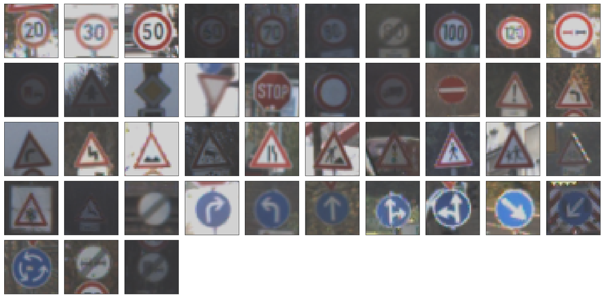

```python
#Toggle required to True to make the preprocess run again
# CAUTION : This takes more than 18+ minutes to process the whole data set
required = False
if (required):
    X_train = preprocess(X_train)
    %%time
    X_valid = preprocess(X_valid)
    %%time
    X_test = preprocess(X_test)
    %%time
    save_processed(X_train, y_train, X_valid, y_valid, X_test, y_test, signnames)
    print("save processed")
else:
    load_processed()


print(X_train.shape, X_train.dtype)
print(X_valid.shape, X_valid.dtype)
print(X_test.shape, X_test.dtype)

plt.figure(figsize=(28, 14))
plt.subplots_adjust(hspace = .1, wspace= .1)
for i in range(0, n_classes):
        index = np.where(y_train==i)[0][0]
        x_selected = X_train[y_train == i]
        image=x_selected[70, :, :, :]
        imp=contr_img(image, 0.65)
        plt.subplot(5, 10, i + 1), plt.imshow(imp)
        plt.xticks([]),plt.yticks([])
plt.savefig('./trafficsigns_processed.jpg')
```

### 2.1 Inception model and LENET ARCHITECTURE

The LeNet model is proposed by Yann LeCun in 1998, it is the most classific cnn model for image recognition, its architecture is as following: [LENET proposal yann.lecun](http://yann.lecun.com/exdb/publis/pdf/lecun-01a.pdf) Gradient-Based Learning algorithms can be used to synthesize a complex decision surface that can classify high-dimensional patterns such as handwritten characters with minimal preprocessing.

[figure not shown]

#### Inception Model

The main idea of the Inception architecture is to consider how an optimal local sparse structure of a convolutional vision network can be approximated and covered by readily available dense components. As these “Inception modules” are stacked on top of each other, their output correlation statistics are bound to vary: as features of higher abstraction are captured by higher layers, their spatial concentration is expected to decrease. This suggests that the ratio of 3×3 and 5×5 convolutions should increase as we move to higher layers.

| Type | Kernel/Stride | Output | Parameters |
| --- | --- | --- | --- |
| conv | 3x3/2x2 | 16x16x64 | 1,792 |
| inception(2a) |  | 16x16x256 | 137,072 |
| inception(2b) |  | 16x16x480 | 388,736 |
| max pool | 3x3/2x2 | 7x7x480 |  |
| inception(3a) |  | 7x7x512 | 433,792 |
| inception(3a) |  | 7x7x512 | 449,160 |
| max pool | 3x3/2x2 | 3x3x512 |  |
| inception(4a) |  | 3x3x832 | 859,136 |
| inception(4a) |  | 3x3x1024 | 1,444,080 |
| avg pool | 3x3/1x1 | 1x1x1024 |  |
| flatten | 864 | 1024 |  |
| full | 43 | 43 | 44,032 |

```python
import tensorflow.contrib.layers as layers

def Inception_Model(inputs, conv11_size, conv33_11_size, conv33_size,conv55_11_size, conv55_size, pool11_size):
    conv11 = layers.conv2d(inputs, conv11_size, [1, 1])
    conv33_reduce = layers.conv2d(inputs, conv33_11_size, [1, 1])
    conv33 = layers.conv2d(conv33_reduce, conv33_size, [3, 3])
    conv55_reduce = layers.conv2d(inputs, conv55_11_size, [1, 1])
    conv55 = layers.conv2d(conv55_reduce, conv55_size, [5, 5])
    pool_proj = layers.max_pool2d(inputs, [3, 3], stride = 1, padding='SAME')
    pool11 = layers.conv2d(pool_proj, pool11_size, [1, 1])
    return tf.concat([conv11, conv33, conv55, pool11], 3)

def LeNet(inputs, dropout_keep_prob): # inputs size:32x32x3
    conv1 = layers.conv2d(inputs, 64, [3, 3], stride = 2) # 16x16x64

    inception_2a = Inception_Model(conv1, 64, 96, 128, 16, 32, 32) # 16x16x256
    inception_2b = Inception_Model(inception_2a, 128, 128, 192, 32, 96, 64) # 16x16x480
    pool2 = layers.max_pool2d(inception_2b, [3, 3]) # 7x7x480 ? why

    inception_3a = Inception_Model(pool2, 192, 96, 208, 16, 48, 64) # 7x7x512
    inception_3b = Inception_Model(inception_3a, 160, 112, 224, 24, 64, 64) # 7x7x512
    pool3 = layers.max_pool2d(inception_3b, [3, 3]) # 3x3x512

    inception_4a = Inception_Model(pool3, 256, 160, 320, 32, 128, 128) # 3x3x832
    inception_4b = Inception_Model(inception_4a, 384, 192, 384, 48, 128, 128) # 3x3x1024
    pool4 = layers.avg_pool2d(inception_4b, [3, 3], stride = 1)

    reshape = tf.reshape(pool4, [-1, 1024])
    dropout = layers.dropout(reshape, dropout_keep_prob)
    logits = layers.fully_connected(dropout, 43, activation_fn=None)

    return logits
```

## 3 Training

### 3.1 Strategy

```python
# tf.placeholder
x = tf.placeholder(tf.float32, (None, 32, 32, 3))
y = tf.placeholder(tf.int32, (None))
one_hot_y = tf.one_hot(y, 43)
keep_prob = tf.placeholder_with_default(1.0, shape=())

# Hyper parameters tuned
#LEARNING_RATE = 2e-5
#LEARNNG_RATE = 3e-5
LEARNING_RATE = 4e-4
#EPOCHS = 30
#EPOCHS = 25
EPOCHS = 35
#BATCH_SIZE=100
BATCH_SIZE = 128

# Training Method
logits = LeNet(x, keep_prob)
cross_entropy = tf.nn.softmax_cross_entropy_with_logits_v2(labels=one_hot_y, logits=logits)
loss_op = tf.reduce_mean(cross_entropy)

#AdamOptimizer https://www.tensorflow.org/api_docs/python/tf/train/AdamOptimizer
optimizer = tf.train.AdamOptimizer(learning_rate = LEARNING_RATE)
train_op = optimizer.minimize(loss_op)
```

### 3.2 Evaluation

```python
correct_prediction = tf.equal(tf.argmax(logits, 1), tf.argmax(one_hot_y, 1))
accuracy_op = tf.reduce_mean(tf.cast(correct_prediction, tf.float32))

def evaluate(X_data, y_data):
    num_examples = len(X_data)
    total_accuracy = 0
    sess = tf.get_default_session()

    for offset in range(0, num_examples, BATCH_SIZE):
        batch_x, batch_y = X_data[offset:offset + BATCH_SIZE], y_data[offset:offset + BATCH_SIZE]
        accuracy = sess.run(accuracy_op, feed_dict={x: batch_x, y: batch_y})
        total_accuracy += (accuracy * len(batch_x))


    return total_accuracy / num_examples
```

## 3.3 Train the Model

A validation set can be used to assess how well the model is performing. A low accuracy on the training and validation sets imply underfitting. A high accuracy on the training set but low accuracy on the validation set implies overfitting.

```python
%%time
saver = tf.train.Saver()
train_accuracy = []
valid_accuracy = []
with tf.Session() as sess:
    sess.run(tf.global_variables_initializer())
    num_examples = len(X_train)
    print("Begining Training...")
    for i in range(EPOCHS):
        X_train, y_train = shuffle(X_train, y_train)
        total_train_acc = 0
        print("EPOCH {} :".format(i+1), end=' ')
        for offset in range(0, num_examples, BATCH_SIZE):
            end = offset + BATCH_SIZE
            batch_x, batch_y = X_train[offset:end], y_train[offset:end]
            _, train_acc = sess.run([train_op, accuracy_op], feed_dict={x: batch_x, y: batch_y, keep_prob: 0.5})
            total_train_acc += (train_acc * len(batch_x))
        train_accuracy.append(total_train_acc / num_examples)
        valid_acc = evaluate(X_valid, y_valid)
        valid_accuracy.append(valid_acc)
        print("Validation Accuracy = {:.3f}".format(valid_acc))

    saver.save(sess, './lenet.ckpt')
    print("Model saved")
```

```
Begining Training...
EPOCH 1 : Validation Accuracy = 0.591
EPOCH 2 : Validation Accuracy = 0.902
EPOCH 3 : Validation Accuracy = 0.920
EPOCH 4 : Validation Accuracy = 0.954
EPOCH 5 : Validation Accuracy = 0.971
EPOCH 6 : Validation Accuracy = 0.959
EPOCH 7 : Validation Accuracy = 0.970
EPOCH 8 : Validation Accuracy = 0.965
EPOCH 9 : Validation Accuracy = 0.971
EPOCH 10 : Validation Accuracy = 0.971
EPOCH 11 : Validation Accuracy = 0.972
EPOCH 12 : Validation Accuracy = 0.958
EPOCH 13 : Validation Accuracy = 0.967
EPOCH 14 : Validation Accuracy = 0.966
EPOCH 15 : Validation Accuracy = 0.974
EPOCH 16 : Validation Accuracy = 0.971
EPOCH 17 : Validation Accuracy = 0.961
EPOCH 18 : Validation Accuracy = 0.978
EPOCH 19 : Validation Accuracy = 0.975
EPOCH 20 : Validation Accuracy = 0.982
EPOCH 21 : Validation Accuracy = 0.980
EPOCH 22 : Validation Accuracy = 0.978
EPOCH 23 : Validation Accuracy = 0.976
EPOCH 24 : Validation Accuracy = 0.981
EPOCH 25 : Validation Accuracy = 0.975
EPOCH 26 : Validation Accuracy = 0.979
EPOCH 27 : Validation Accuracy = 0.976
EPOCH 28 : Validation Accuracy = 0.979
EPOCH 29 : Validation Accuracy = 0.980
EPOCH 30 : Validation Accuracy = 0.980
EPOCH 31 : Validation Accuracy = 0.981
EPOCH 32 : Validation Accuracy = 0.979
EPOCH 33 : Validation Accuracy = 0.986
EPOCH 34 : Validation Accuracy = 0.978
EPOCH 35 : Validation Accuracy = 0.986
Model saved
CPU times: user 8min 17s, sys: 1min 17s, total: 9min 34s
Wall time: 10min 33s
```

Plot the accuracy of training and validation operation

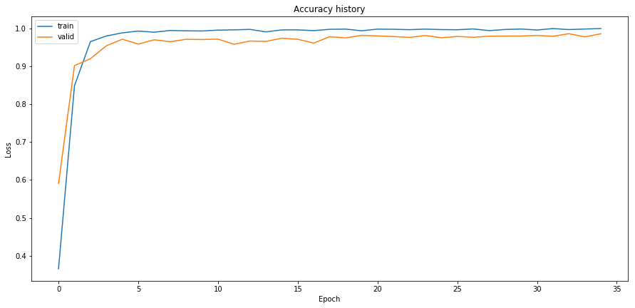

```python
plt.subplot(2, 1, 2)
plt.plot(train_accuracy, label='train')
plt.plot(valid_accuracy, label='valid')
plt.title('Accuracy history')
plt.xlabel('Epoch')
plt.ylabel('Loss')
plt.gcf().set_size_inches(15, 15)
plt.legend()
plt.show()
```

### Train, Validate and Test the Model

A validation set can be used to assess how well the model is performing. A low accuracy on the training and validation sets imply underfitting. A high accuracy on the training set but low accuracy on the validation set implies overfitting.

```
INFO:tensorflow:Restoring parameters from ./lenet.ckpt
```

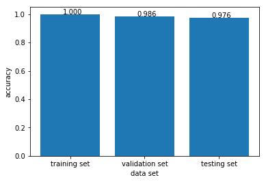

```python
with tf.Session() as sess:
    saver.restore(sess, './lenet.ckpt')
#     sess.run(tf.global_variables_initializer())
    train_accuracy = evaluate(X_train, y_train)
    valid_accuracy = evaluate(X_valid, y_valid)
    test_accuracy = evaluate(X_test, y_test)

accuracys = [train_accuracy, valid_accuracy, test_accuracy]
tick_labels = ["training set", "validation set", "testing set"]
plt.bar(range(3), accuracys)
plt.xlabel('data set')
plt.ylabel('accuracy')
plt.xticks(range(3), tick_labels)
for x_,y_ in zip(range(3), accuracys):
    plt.text(x_ - 0.1, y_, '%.3f'%y_)
plt.show()
```

## Step 3: Test a Model on New Images

To give yourself more insight into how your model is working, download at least five pictures of German traffic signs from the web and use your model to predict the traffic sign type.

You may find `signnames.csv` useful as it contains mappings from the class id (integer) to the actual sign name.

### Load and Output the Images

```python
### Load the images and plot them here.
### Feel free to use as many code cells as needed.
new_test_images = []
path = './german_traffic_signs/'
for image in os.listdir(path):
    img = cv2.imread(path + image)
    img = cv2.resize(img,(32, 32), interpolation = cv2.INTER_CUBIC)
    img = cv2.cvtColor(img, cv2.COLOR_BGR2RGB)
    new_test_images.append(img)
new_IDs = [ 3, 14, 27, 17, 13]
print("Number of new testing examples: ", len(new_test_images))
```

```
Number of new testing examples:  5
```

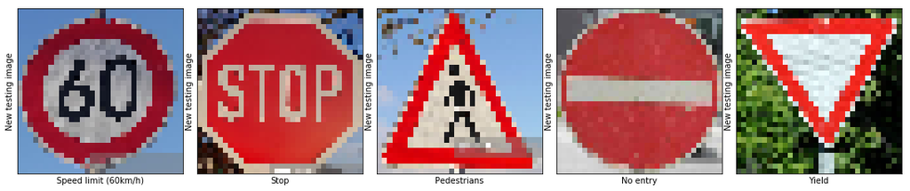

```python
plt.figure(figsize=(15, 16))
for i in range(len(new_test_images)):
    plt.subplot(2, 5, i+1)
    plt.imshow(new_test_images[i])
    plt.xlabel(signs[new_IDs[i]])
    plt.ylabel("New testing image")
    plt.xticks([])
    plt.yticks([])
plt.tight_layout(pad=0, h_pad=0, w_pad=0)
plt.show()
```

### Predict the Sign Type for Each Image

```python
### Run the predictions here and use the model to output the prediction for each image.
### Make sure to pre-process the images with the same pre-processing pipeline used earlier.
### Feel free to use as many code cells as needed.
with tf.Session() as sess:
    saver.restore(sess, './lenet.ckpt')
    test_accuracy = evaluate(new_test_images, new_IDs)
    print("Test Accuracy = {:.3f}".format(test_accuracy))
    logits_value = sess.run(logits, feed_dict={x: new_test_images})
    probabilities = sess.run(tf.nn.softmax(logits_value))

predict = probabilities.argmax(axis=1)
print("Predict the Labels Type for Each Image")
print(predict)
```

```
INFO:tensorflow:Restoring parameters from ./lenet.ckpt
Test Accuracy = 0.800
Predict the Labels Type for Each Image
[ 3 14 24 17 13]
```

### Analyze Performance

```python
### Calculate the accuracy for these 5 new images.
### For example, if the model predicted 1 out of 5 signs correctly, it's 20% accurate on these new images.
```

### Output Top 5 Softmax Probabilities For Each Image Found on the Web

For each of the new images, print out the model's softmax probabilities to show the **certainty** of the model's predictions (limit the output to the top 5 probabilities for each image). [`tf.nn.top_k`](https://www.tensorflow.org/versions/r0.12/api_docs/python/nn.html#top_k) could prove helpful here.

The example below demonstrates how tf.nn.top_k can be used to find the top k predictions for each image.

`tf.nn.top_k` will return the values and indices (class ids) of the top k predictions. So if k=3, for each sign, it'll return the 3 largest probabilities (out of a possible 43) and the correspoding class ids.

Take this numpy array as an example. The values in the array represent predictions. The array contains softmax probabilities for five candidate images with six possible classes. `tf.nn.top_k` is used to choose the three classes with the highest probability:

```
# (5, 6) array
a = np.array([[ 0.24879643,  0.07032244,  0.12641572,  0.34763842,  0.07893497,
         0.12789202],
       [ 0.28086119,  0.27569815,  0.08594638,  0.0178669 ,  0.18063401,
         0.15899337],
       [ 0.26076848,  0.23664738,  0.08020603,  0.07001922,  0.1134371 ,
         0.23892179],
       [ 0.11943333,  0.29198961,  0.02605103,  0.26234032,  0.1351348 ,
         0.16505091],
       [ 0.09561176,  0.34396535,  0.0643941 ,  0.16240774,  0.24206137,
         0.09155967]])
```

Running it through `sess.run(tf.nn.top_k(tf.constant(a), k=3))` produces:

```
TopKV2(values=array([[ 0.34763842,  0.24879643,  0.12789202],
       [ 0.28086119,  0.27569815,  0.18063401],
       [ 0.26076848,  0.23892179,  0.23664738],
       [ 0.29198961,  0.26234032,  0.16505091],
       [ 0.34396535,  0.24206137,  0.16240774]]), indices=array([[3, 0, 5],
       [0, 1, 4],
       [0, 5, 1],
       [1, 3, 5],
       [1, 4, 3]], dtype=int32))
```

Looking just at the first row we get `[ 0.34763842, 0.24879643, 0.12789202]`, you can confirm these are the 3 largest probabilities in `a`. You'll also notice `[3, 0, 5]` are the corresponding indices.

```
INFO:tensorflow:Restoring parameters from ./lenet.ckpt
New Images Test Accuracy = 80.0%
```

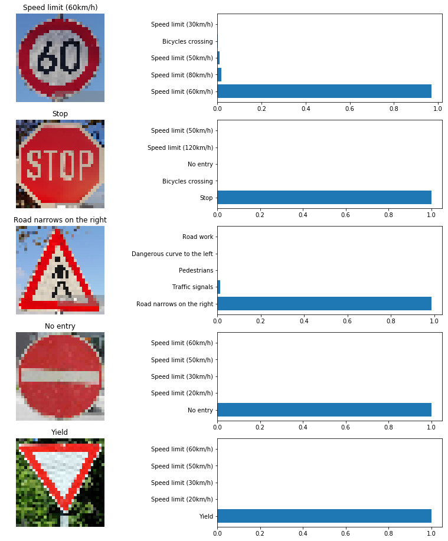

```python
### Print out the top five softmax probabilities for the predictions on the German traffic sign images found on the web.
### Feel free to use as many code cells as needed.
new_test_images_preprocessed = preprocess(np.asarray(new_test_images))

def predict_model(Input_data, top_k=5):
    """
    Generates the predictions of the model over the input data, and outputs the top softmax probabilities.
        Parameters:
            X_data: Input data.
            top_k (Default = 5): The number of top softmax probabilities to be generated.
    """
    num_examples = len(Input_data)
    y_pred = np.zeros((num_examples, top_k), dtype=np.int32)
    y_prob = np.zeros((num_examples, top_k))
    with tf.Session() as sess:
            saver.restore(sess, './lenet.ckpt')
            y_prob, y_pred = sess.run(tf.nn.top_k(tf.nn.softmax(logits), k=top_k),
                             feed_dict={x: new_test_images})
    return y_prob, y_pred

y_prob, y_pred = predict_model(new_test_images_preprocessed)

test_accuracy = 0
for i in enumerate(new_test_images_preprocessed):
    accu = new_IDs[i[0]] == np.asarray(y_pred[i[0]])[0]
    if accu == True:
        test_accuracy += 0.2
print("New Images Test Accuracy = {:.1f}%".format(test_accuracy*100))

plt.figure(figsize=(15, 16))
for i in range(len(new_test_images_preprocessed)):
    plt.subplot(5, 2, 2*i+1)
    plt.imshow(new_test_images[i])
    plt.title(signs[y_pred[i][0]])
    plt.axis('off')
    plt.subplot(5, 2, 2*i+2)
    plt.barh(np.arange(1, 6, 1), y_prob[i, :])
    labels = [signs[j] for j in y_pred[i]]
    plt.yticks(np.arange(1, 6, 1), labels)
plt.show()
```

### Project Writeup

Once you have completed the code implementation, document your results in a project writeup using this [template](https://github.com/udacity/CarND-Traffic-Sign-Classifier-Project/blob/master/writeup_template.md) as a guide. The writeup can be in a markdown or pdf file.

> **Note**: Once you have completed all of the code implementations and successfully answered each question above, you may finalize your work by exporting the iPython Notebook as an HTML document. You can do this by using the menu above and navigating to \n", "**File -> Download as -> HTML (.html)**. Include the finished document along with this notebook as your submission.